# Using Caret to solve classification problems

# Introduction

Many applications, many different methods = many different packages in R.

The caret package wraps many implementations of classification methods into a common framework to standarise the input and output. Useful for comparing performance of different methods on the same data.

See https://topepo.github.io/caret/index.html for very detailed documentation.

# Load the libraries

```r
library(DT)
library(ggplot2)
library(cowplot)
library(caret)
library(gbm)
library(randomForest)
library(nnet)
```

If not on windows, can use the doMC package to run the code in paralel

```r
library(doMC)
registerDoMC(cores = 5)
```

# Exploratory analysis

### How many variables and observations?

```r
dim(iris)
```

```
## [1] 150   5
```

### Get a feel for the data

```r
datatable(iris,rownames = F)
```

| Sepal.Length | Sepal.Width | Petal.Length | Petal.Width | Species |
| --- | --- | --- | --- | --- |
| 5.1 | 3.5 | 1.4 | 0.2 | setosa |
| 4.9 | 3 | 1.4 | 0.2 | setosa |
| 4.7 | 3.2 | 1.3 | 0.2 | setosa |
| 4.6 | 3.1 | 1.5 | 0.2 | setosa |
| 5 | 3.6 | 1.4 | 0.2 | setosa |
| 5.4 | 3.9 | 1.7 | 0.4 | setosa |
| 4.6 | 3.4 | 1.4 | 0.3 | setosa |
| 5 | 3.4 | 1.5 | 0.2 | setosa |
| 4.4 | 2.9 | 1.4 | 0.2 | setosa |
| 4.9 | 3.1 | 1.5 | 0.1 | setosa |

[output cut: 140 more lines]

```r
summary(iris)
```

```
##   Sepal.Length    Sepal.Width     Petal.Length    Petal.Width
##  Min.   :4.300   Min.   :2.000   Min.   :1.000   Min.   :0.100
##  1st Qu.:5.100   1st Qu.:2.800   1st Qu.:1.600   1st Qu.:0.300
##  Median :5.800   Median :3.000   Median :4.350   Median :1.300
##  Mean   :5.843   Mean   :3.057   Mean   :3.758   Mean   :1.199
##  3rd Qu.:6.400   3rd Qu.:3.300   3rd Qu.:5.100   3rd Qu.:1.800
##  Max.   :7.900   Max.   :4.400   Max.   :6.900   Max.   :2.500
##        Species
##  setosa    :50
##  versicolor:50
##  virginica :50
##
##
##
```

### PCA

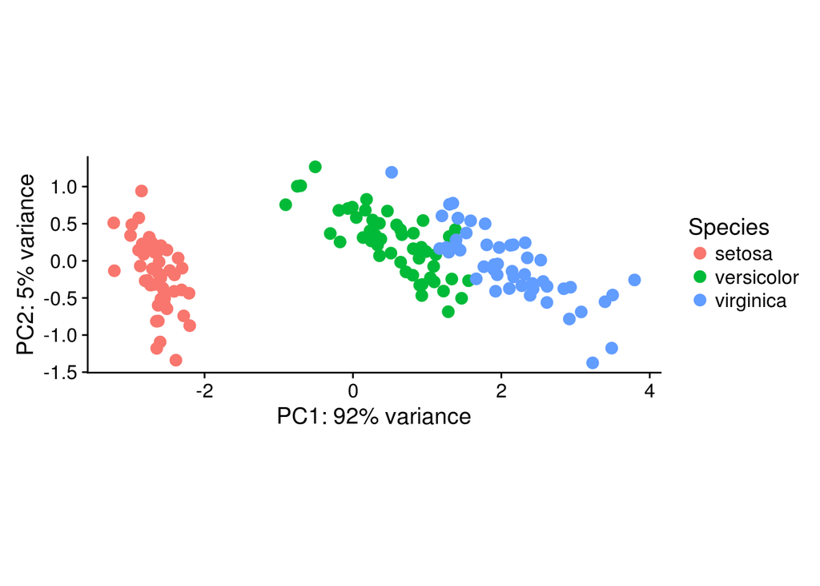

```r
#perform a PCA on the data in assay(x) for the selected genes
pca <- prcomp(iris[,-5])

# the contribution to the total variance for each component
percentVar <- pca$sdev^2 / sum( pca$sdev^2 )

# assemble the data for the plot
d <- data.frame(PC1=pca$x[,1], PC2=pca$x[,2],species=as.factor(iris$Species))

ggplot(data=d, aes(x=PC1, y=PC2, colour=species)) + geom_point(size=3) + xlab(paste0("PC1: ",round(percentVar[1] * 100),"% variance")) + ylab(paste0("PC2: ",round(percentVar[2] * 100),"% variance")) +  coord_fixed() + scale_colour_discrete(name="Species") + theme_cowplot()
```

### What features are likely to be discriminative?

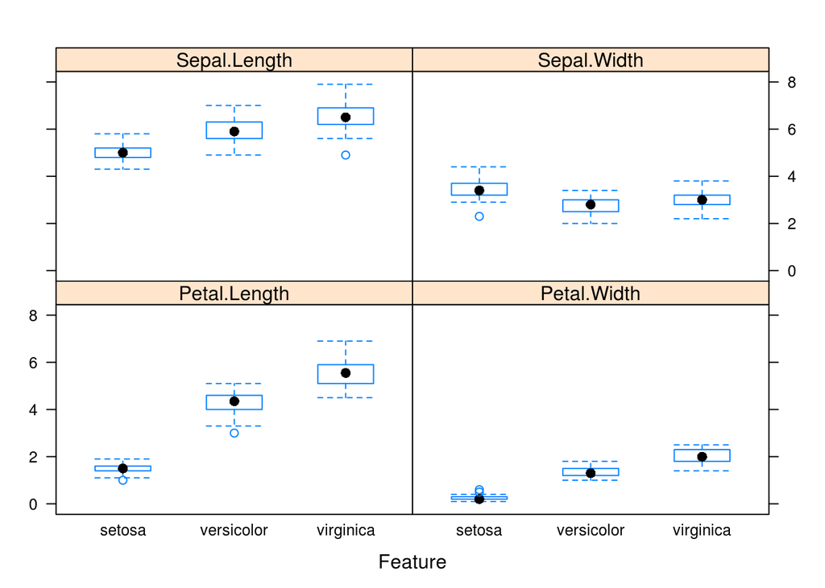

```r
featurePlot(iris[,1:4],as.factor(iris[,5]), plot="boxplot")
```

# Create training and test datasets

The createDataPartition splits the data into a test and training dataset. We will use the training set to optimise the predictive model while the test dataset can be used to simulate new data.

```r
set.seed(42)
trainIndex <- createDataPartition(iris$Species, p = .8,
                                  list = FALSE,
                                  times = 1)
irisTrain <- iris[ trainIndex,]
irisTest  <- iris[-trainIndex,]

table(irisTest$Species)
```

```
##
##     setosa versicolor  virginica
##         10         10         10
```

# Train a model

Can use the trainControl function to set up the cross-validation method. We optimise the the model by choosing the best parameters within the training dataset. The dataset is split into 10 parts/ 9 parts are used for training the model with a given set of parameters and one part for testing the performance.

```r
# 10-fold CV repeated 10 times
fitControl <- trainControl(method = "repeatedcv",
                           number = 10,
                           repeats = 50)
```

Get the parameters for the knn model

```r
getModelInfo("knn",regex = F)
```

```
## $knn
## $knn$label
## [1] "k-Nearest Neighbors"
##
## $knn$library
## NULL
##
## $knn$loop
## NULL
##
## $knn$type
## [1] "Classification" "Regression"
##
## $knn$parameters
##   parameter   class      label
## 1         k numeric #Neighbors
##
## $knn$grid
## function (x, y, len = NULL, search = "grid")
## {
##     if (search == "grid") {
##         out <- data.frame(k = (5:((2 * len) + 4))[(5:((2 * len) +
##             4))%%2 > 0])
##     }
##     else {
##         by_val <- if (is.factor(y))
##             length(levels(y))
##         else 1
##         out <- data.frame(k = sample(seq(1, floor(nrow(x)/3),
##             by = by_val), size = len, replace = TRUE))
##     }
##     out
## }
##
## $knn$fit
## function (x, y, wts, param, lev, last, classProbs, ...)
## {
##     if (is.factor(y)) {
##         knn3(as.matrix(x), y, k = param$k, ...)
##     }
```

[output cut: 20 more lines]

```
##
## $knn$tags
## [1] "Prototype Models"
##
## $knn$prob
## function (modelFit, newdata, submodels = NULL)
## predict(modelFit, newdata, type = "prob")
##
## $knn$levels
## function (x)
## levels(x$learn$y)
##
## $knn$sort
## function (x)
## x[order(-x[, 1]), ]
```

Set up the search grid for the model

```r
knnGrid <- expand.grid(k=1:10)
```

Train the model

```r
set.seed(42)
knnFit <- train(Species~ ., data = irisTrain,
                 method = "knn",
                 trControl = fitControl,
                 tuneGrid=knnGrid
                )
knnFit
```

```
## k-Nearest Neighbors
##
## 120 samples
##   4 predictors
##   3 classes: 'setosa', 'versicolor', 'virginica'
##
## No pre-processing
## Resampling: Cross-Validated (10 fold, repeated 50 times)
## Summary of sample sizes: 108, 108, 108, 108, 108, 108, ...
## Resampling results across tuning parameters:
##
##   k   Accuracy   Kappa
##    1  0.9413333  0.91200
##    2  0.9301667  0.89525
##    3  0.9450000  0.91750
##    4  0.9403333  0.91050
##    5  0.9476667  0.92150
##    6  0.9483333  0.92250
##    7  0.9468333  0.92025
##    8  0.9460000  0.91900
##    9  0.9465000  0.91975
##   10  0.9473333  0.92100
##
## Accuracy was used to select the optimal model using  the largest value.
## The final value used for the model was k = 6.
```

Plot the resampling profiles

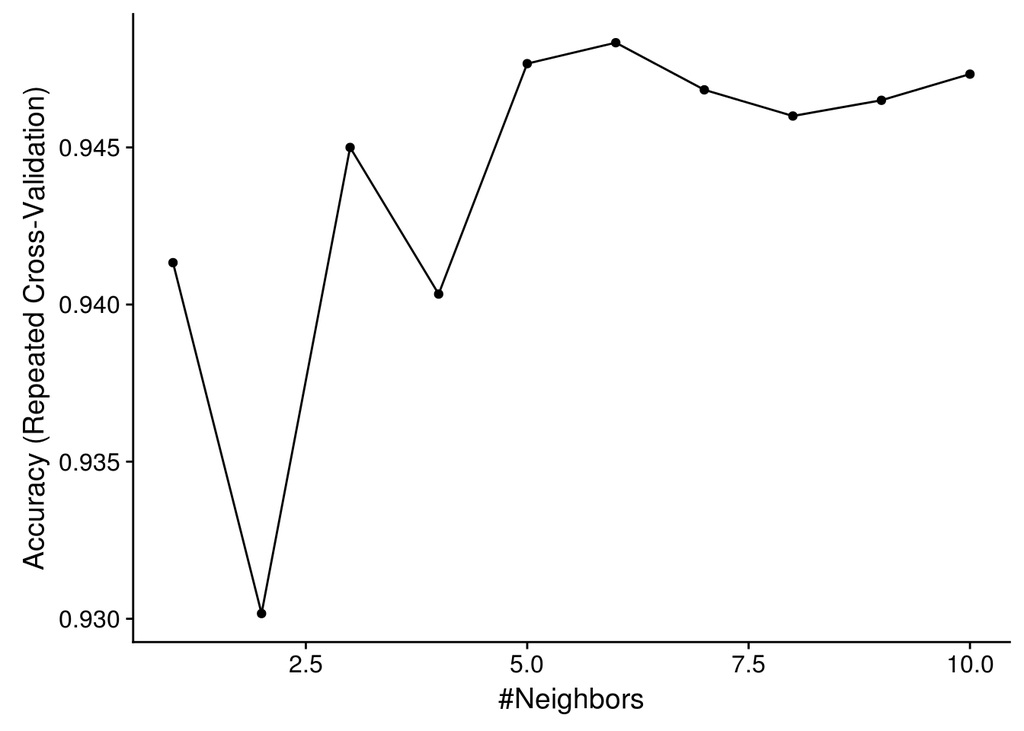

```r
ggplot(knnFit)
```

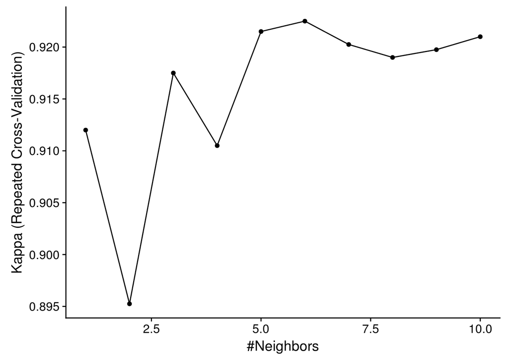

```r
ggplot(knnFit,metric = "Kappa")
```

# Make predictions using the best model

```r
#Predict the samples in the training set with the best model
confusionMatrix(knnFit)
```

```
## Cross-Validated (10 fold, repeated 50 times) Confusion Matrix
##
## (entries are percentual average cell counts across resamples)
##
##             Reference
## Prediction   setosa versicolor virginica
##   setosa       33.3        0.0       0.0
##   versicolor    0.0       30.7       2.5
##   virginica     0.0        2.6      30.8
##
##  Accuracy (average) : 0.9483
```

# Train other models for comparison

```r
#RandomForest
set.seed(42)
rfFit <- train(Species~ ., data = irisTrain,
                 method = "rf",
                 trControl = fitControl
                )
rfFit
```

```
## Random Forest
##
## 120 samples
##   4 predictors
##   3 classes: 'setosa', 'versicolor', 'virginica'
##
## No pre-processing
## Resampling: Cross-Validated (10 fold, repeated 50 times)
## Summary of sample sizes: 108, 108, 108, 108, 108, 108, ...
## Resampling results across tuning parameters:
##
##   mtry  Accuracy   Kappa
##   2     0.9396667  0.90950
##   3     0.9461667  0.91925
##   4     0.9456667  0.91850
##
## Accuracy was used to select the optimal model using  the largest value.
## The final value used for the model was mtry = 3.
```

```r
#Support Vector Machine
set.seed(42)
svmGrid <- expand.grid(C= 2^c(0:5))
svmFit <- train(Species~ ., data = irisTrain,
                 method = "svmLinear",
                 trControl = fitControl,
                tuneGrid=svmGrid
                )
svmFit
```

```
## Support Vector Machines with Linear Kernel
##
## 120 samples
##   4 predictors
##   3 classes: 'setosa', 'versicolor', 'virginica'
##
## No pre-processing
## Resampling: Cross-Validated (10 fold, repeated 50 times)
## Summary of sample sizes: 108, 108, 108, 108, 108, 108, ...
## Resampling results across tuning parameters:
##
##   C   Accuracy   Kappa
##    1  0.9496667  0.92450
##    2  0.9538333  0.93075
##    4  0.9556667  0.93350
##    8  0.9528333  0.92925
##   16  0.9498333  0.92475
##   32  0.9520000  0.92800
##
## Accuracy was used to select the optimal model using  the largest value.
## The final value used for the model was C = 4.
```

```r
#Gradient Boosted Model
set.seed(42)
gbmFit <- train(Species~ ., data = irisTrain,
                 method = "gbm",
                 trControl = fitControl,
                verbose=F
                )
gbmFit
```

```
## Stochastic Gradient Boosting
##
## 120 samples
##   4 predictors
##   3 classes: 'setosa', 'versicolor', 'virginica'
##
## No pre-processing
## Resampling: Cross-Validated (10 fold, repeated 50 times)
## Summary of sample sizes: 108, 108, 108, 108, 108, 108, ...
## Resampling results across tuning parameters:
##
##   interaction.depth  n.trees  Accuracy   Kappa
##   1                   50      0.9335000  0.90025
##   1                  100      0.9273333  0.89100
##   1                  150      0.9233333  0.88500
##   2                   50      0.9321667  0.89825
##   2                  100      0.9255000  0.88825
##   2                  150      0.9223333  0.88350
##   3                   50      0.9296667  0.89450
##   3                  100      0.9251667  0.88775
##   3                  150      0.9218333  0.88275
##
## Tuning parameter 'shrinkage' was held constant at a value of 0.1
##
## Tuning parameter 'n.minobsinnode' was held constant at a value of 10
## Accuracy was used to select the optimal model using  the largest value.
## The final values used for the model were n.trees = 50, interaction.depth
##  = 1, shrinkage = 0.1 and n.minobsinnode = 10.
```

```r
#Neural Network
set.seed(42)
nnFit <- train(Species~ ., data = irisTrain,
                 method = "nnet",
                 trControl = fitControl,
                maxit = 1000,
               trace=FALSE
                )
nnFit
```

```
## Neural Network
##
## 120 samples
##   4 predictors
##   3 classes: 'setosa', 'versicolor', 'virginica'
##
## No pre-processing
## Resampling: Cross-Validated (10 fold, repeated 50 times)
## Summary of sample sizes: 108, 108, 108, 108, 108, 108, ...
## Resampling results across tuning parameters:
##
##   size  decay  Accuracy   Kappa
##   1     0e+00  0.7755000  0.66325
##   1     1e-04  0.8708333  0.80625
##   1     1e-01  0.9420000  0.91300
##   3     0e+00  0.9018333  0.85275
##   3     1e-04  0.9455000  0.91825
##   3     1e-01  0.9616667  0.94250
##   5     0e+00  0.9286667  0.89300
##   5     1e-04  0.9458333  0.91875
##   5     1e-01  0.9620000  0.94300
##
## Accuracy was used to select the optimal model using  the largest value.
## The final values used for the model were size = 5 and decay = 0.1.
```

# Compare the model performance

```r
models <- resamples(list(knn=knnFit,rf=rfFit,svm=svmFit,gbm=gbmFit,nn=nnFit))
summary(models)
```

```
##
## Call:
## summary.resamples(object = models)
##
## Models: knn, rf, svm, gbm, nn
## Number of resamples: 500
##
## Accuracy
##       Min. 1st Qu. Median   Mean 3rd Qu. Max. NA's
## knn 0.7500  0.9167 0.9167 0.9483       1    1    0
## rf  0.7500  0.9167 0.9167 0.9462       1    1    0
## svm 0.7500  0.9167 1.0000 0.9557       1    1    0
## gbm 0.6667  0.9167 0.9167 0.9335       1    1    0
## nn  0.7500  0.9167 1.0000 0.9620       1    1    0
##
## Kappa
##      Min. 1st Qu. Median   Mean 3rd Qu. Max. NA's
## knn 0.625   0.875  0.875 0.9225       1    1    0
## rf  0.625   0.875  0.875 0.9192       1    1    0
## svm 0.625   0.875  1.000 0.9335       1    1    0
## gbm 0.500   0.875  0.875 0.9002       1    1    0
## nn  0.625   0.875  1.000 0.9430       1    1    0
```

# Predict the test dataset samples

```r
predictions<-predict(nnFit,irisTest)
confusionMatrix(predictions,irisTest$Species )
```

```
## Confusion Matrix and Statistics
##
##             Reference
## Prediction   setosa versicolor virginica
##   setosa         10          0         0
##   versicolor      0         10         0
##   virginica       0          0        10
##
## Overall Statistics
##
##                Accuracy : 1
##                  95% CI : (0.8843, 1)
##     No Information Rate : 0.3333
##     P-Value [Acc > NIR] : 4.857e-15
##
##                   Kappa : 1
##  Mcnemar's Test P-Value : NA
##
## Statistics by Class:
##
##                      Class: setosa Class: versicolor Class: virginica
## Sensitivity                 1.0000            1.0000           1.0000
## Specificity                 1.0000            1.0000           1.0000
## Pos Pred Value              1.0000            1.0000           1.0000
## Neg Pred Value              1.0000            1.0000           1.0000
## Prevalence                  0.3333            0.3333           0.3333
## Detection Rate              0.3333            0.3333           0.3333
## Detection Prevalence        0.3333            0.3333           0.3333
## Balanced Accuracy           1.0000            1.0000           1.0000
```